# parent_child_metric_analysis_watseq_vs_tauschii

```python
from IPython.core.display import display, HTML
display(HTML("<style>.container { width:100% !important; }</style>"))
```

## Aim:

- Understand the genome regions where we are AP fail to correctly call haplotyepes. ### Rationale:
- We. observed that "orphan" windows in our parent-child QC, have particular features. high number of haplotipes, low number of windows in the bloch of windwos low variance, etc...
- In this analysis we wanted to test if we can detect those features to propose a potential solution.
- We want to know how those features move when we change the size of block of windows, reference, sliding windows, wtc.. ### Work:
- We are looking at the `'w_num','dmp_num','std', 'median', 'mean', 'variance', 'skew', 'kurt'` metrics per block of windows ### Results:
- w_num: number of sub-windows in the block of windows: in this example seems that the number of windows in the "orphan" category are similar (we have to test an ANOVA maybe). Note that some chromosome have much less number of windows in all categories, those may be unique regions in the "arina" reference. Overal most chromosomes have similar number of windwos.
- dmp_num: number of haplotypes per windows: in this ezample, all categories have similar number of windows (slighly more in the "orphan" category"), but seems that the "orphan" category have many outliers with high number of windows.
- variance & std: standar deviation: as predicted, the orphans have small variance & std in all chromosomes and much less in the D-subgenome
- median & mean: similar to the std, the orphans have small median & mean in all chromosomes and much less in the D-subgenome
- skew & kurt: `negative skew indicates that the tail is on the left side of the distribution, and positive skew indicates that the tail is on the righ`: orphans tend to have positive skew, tail on the right, wich indicates that most of the variations are in the low count and a few are in the high count category (we should see the oposite where there are introgressions (Lancer, chr 2B).

## See at the bottom the other parent-childs, they behave similar.# NOTE: the order and color of the orphan change (I'll fix this)

```python
import pandas as pd
import numpy as np
import matplotlib.pyplot as plt
import seaborn as sns
```

```python
watseq = pd.read_csv('arinalrfor_parent_child_by_block_stats.tsv', delimiter='\t')
watseq_D = watseq[watseq['chr'].str.contains('D')]
watseq_D.columns= tauschii.columns.str.lower()
tauschii = pd.read_csv('arinalrfor_parent_child_by_block_stats_tauschii.tsv.gz', delimiter='\t')
tauschii[['Xi19_parent','Maris_Widgeon_parent','Claire_parent']] = tauschii[['Xi19_parent','Maris_Widgeon_parent','Claire_parent']].astype(str) + '_tau'
tauschii.columns= tauschii.columns.str.lower()
df_combined = pd.concat([watseq_D,tauschii])
df_combined['xi19_parent'] = df_combined['xi19_parent'].str.lower()
df_combined
```

|  | chr | start | end | w_num | dmp_num | std | median | mean | variance | skew | ... | dmp_max-xi19 | dmp_max-cappelle_desprez | dmp_max-holdfast | dmp_max-maris_widgeon | dmp_max-flame | dmp_max-wasp | dmp_max-claire | xi19_parent | maris_widgeon_parent | claire_parent |
| --- | --- | --- | --- | --- | --- | --- | --- | --- | --- | --- | --- | --- | --- | --- | --- | --- | --- | --- | --- | --- | --- |
| 1301 | chr1D__ari | 1 | 1000000 | 151 | 14 | 190.0 | 54.0 | 170.0 | 36084.3 | 1.02 | ... | 6 | 8 | 11 | 11 | 10 | 8 | 8 | rialto | Holdfast | wasp |
| 1302 | chr1D__ari | 1000001 | 2000000 | 129 | 12 | 229.7 | 75.0 | 212.8 | 52766.2 | 0.80 | ... | 7 | 9 | 1 | 1 | 9 | 9 | 9 | rialto | Holdfast | all_ibs |
| 1303 | chr1D__ari | 2000001 | 3000000 | 111 | 3 | 172.6 | 64.0 | 162.6 | 29787.7 | 0.87 | ... | 2 | 2 | 2 | 2 | 2 | 2 | 2 | all_ibs | all_ibs | all_ibs |
| 1304 | chr1D__ari | 3000001 | 4000000 | 105 | 22 | 116.8 | 23.0 | 57.1 | 13647.9 | 3.44 | ... | 12 | 13 | 11 | 18 | 13 | 21 | 12 | orphan | orphan | orphan |
| 1305 | chr1D__ari | 4000001 | 5000000 | 136 | 13 | 122.3 | 22.0 | 60.2 | 14953.5 | 3.12 | ... | 0 | 10 | 10 | 10 | 10 | 2 | 0 | rialto | all_ibs | orphan |
| ... | ... | ... | ... | ... | ... | ... | ... | ... | ... | ... | ... | ... | ... | ... | ... | ... | ... | ... | ... | ... | ... |
| 3973 | chr7D__ari | 638000001 | 639000000 | 144 | 36 | 175.3 | 25.0 | 107.0 | 30729.9 | 1.88 | ... | 32 | 32 | 32 | 32 | 32 | 32 | 32 | cadenza_tau | all_ibs_tau | all_ibs_tau |
| 3974 | chr7D__ari | 639000001 | 640000000 | 127 | 56 | 146.2 | 27.0 | 96.6 | 21372.4 | 1.75 | ... | 51 | 51 | 47 | 51 | 51 | 51 | 51 | all_ibs_tau | Cappelle_Desprez_tau | all_ibs_tau |
| 3975 | chr7D__ari | 640000001 | 641000000 | 123 | 41 | 153.7 | 26.0 | 105.4 | 23620.8 | 1.68 | ... | 33 | 33 | 35 | 33 | 33 | 33 | 33 | all_ibs_tau | Cappelle_Desprez_tau | all_ibs_tau |
| 3976 | chr7D__ari | 641000001 | 642000000 | 127 | 4 | 161.7 | 27.0 | 113.0 | 26137.7 | 1.52 | ... | 3 | 3 | 0 | 3 | 3 | 3 | 3 | cadenza_tau | Cappelle_Desprez_tau | all_ibs_tau |
| 3977 | chr7D__ari | 642000001 | 642300000 | 28 | 9 | 126.0 | 24.0 | 80.1 | 15872.1 | 2.30 | ... | 7 | 7 | 7 | 7 | 7 | 7 | 7 | all_ibs_tau | all_ibs_tau | all_ibs_tau |

7956 rows × 23 columns

```python
def plot_metrics(df, metric, child, fig_size):
    plt.figure(figsize=fig_size)
    df.sort_values(by=['chr',f'{child}_parent'],inplace=True)
    sns.set_theme(style="ticks", palette="pastel")
#     palette = ['tab:blue','tab:gray','tab:cyan','tab:orange']
    ax = sns.boxplot(x='chr', y=metric, hue=f'{child}_parent', data=df, palette='pastel')
    sns.despine(offset=10, trim=True, ax=ax)
    ax.set_title(f'metric: {metric}, child: {child}', fontsize=15, fontweight="bold")
    ax.axes.get_xaxis().get_label().set_visible(False)
    plt.ylabel(metric,fontsize=15,fontweight="bold")
#     plt.setp(ax.get_xticklabels(), rotation=90, fontsize=9)
```

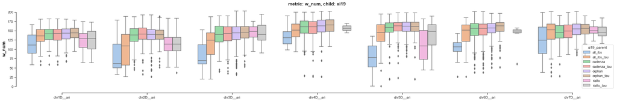

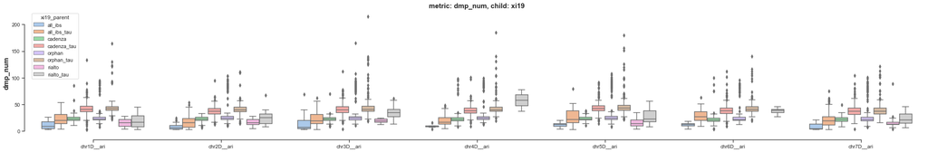

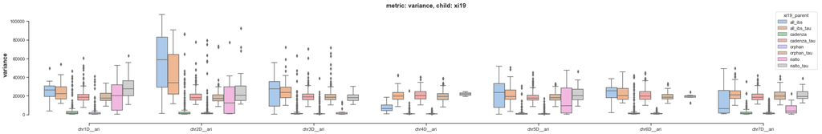

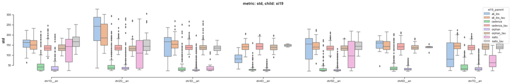

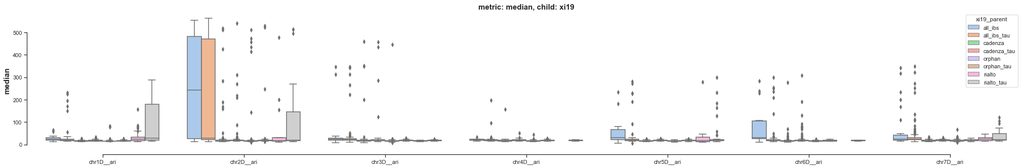

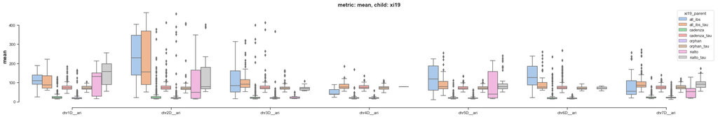

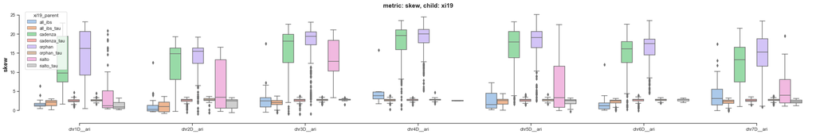

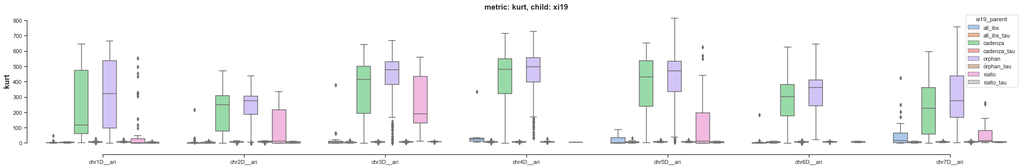

```python
child='xi19'
metrics=['w_num','dmp_num','variance','std', 'median', 'mean', 'skew', 'kurt']
fig_size=(35,5)
for metric in metrics:
    plot_metrics(df_combined, metric, child, fig_size)
```

## Maris_Widgeon

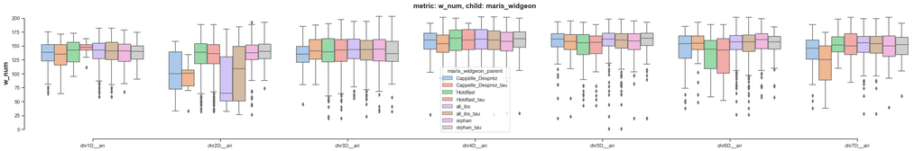

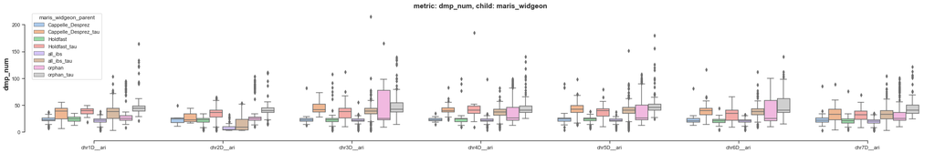

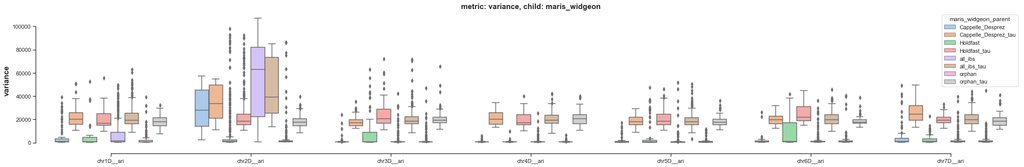

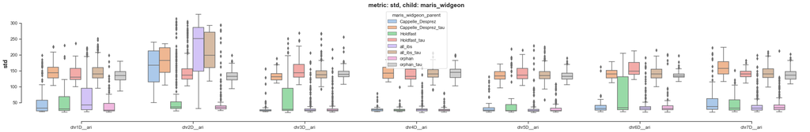

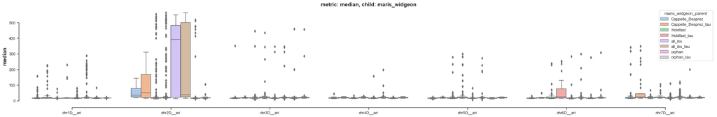

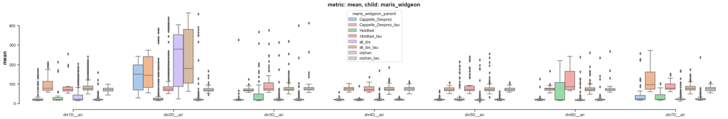

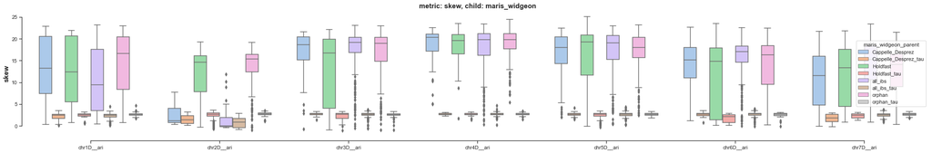

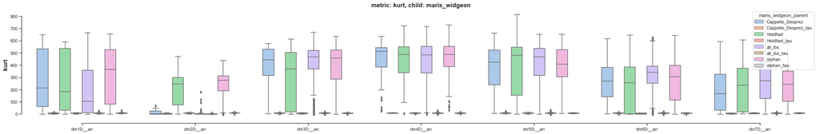

```python
child='maris_widgeon'
metrics=['w_num','dmp_num','variance','std', 'median', 'mean', 'skew', 'kurt']
fig_size=(35,5)
for metric in metrics:
    plot_metrics(df_combined, metric, child, fig_size)
```

## Claire

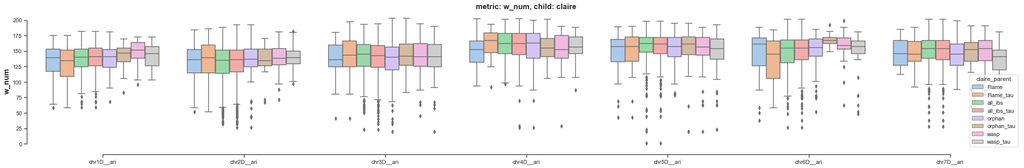

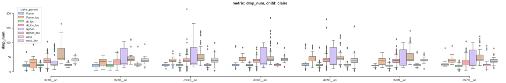

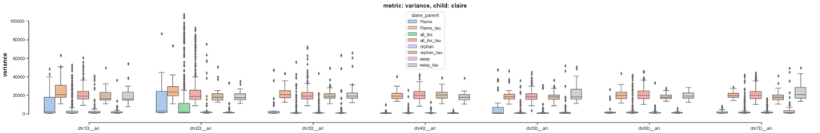

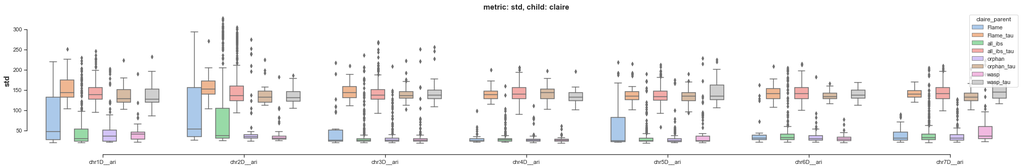

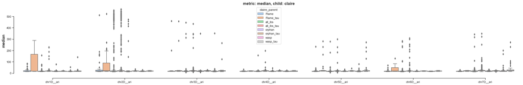

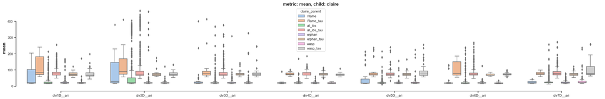

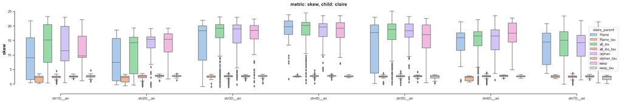

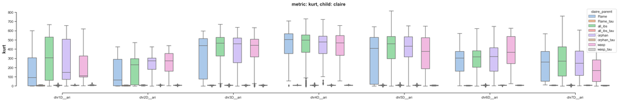

```python
child='claire'
metrics=['w_num','dmp_num','variance','std', 'median', 'mean', 'skew', 'kurt']
fig_size=(35,5)
for metric in metrics:
    plot_metrics(df_combined, metric, child, fig_size)
```